# Practical Machine Learning Week 4 Project

SR

04/28/2021

```r
library(caret)
library(randomForest)
```

```r
library(rpart)
library(rpart.plot)
library(lattice)
library(ggplot2)
library(rattle)
```

## Summary of analysis

This project is to study data from accelerometers on the belts, forearms and arms of six participants, and on the dumbells to determine how well they perform lifting dumbells. To provide input information, the participants were asked to perform lifting correctly and incorrectly in 5 different ways. The goal of this project is to predict the manner in which they did the exercise.

## Loading and cleaning data

Load the training and test data sets and remove the NA,#DIV/0! and blank values in the data. Then the datasets were subsetted to remove columns 1-7 with irrelevant information.

```r
training_data <- read.csv('pml-training.csv', na.strings = c("NA", "#DIV/0!", ""))
testing_data <- read.csv('pml-testing.csv', na.strings = c("NA", "#DIV/0!", ""))
dim(training_data)
```

```
## [1] 19622   160
```

```r
dim(testing_data)
```

```
## [1]  20 160
```

```r
training_data <- training_data[,colSums(is.na(training_data)) == 0]
testing_data <- testing_data[,colSums(is.na(testing_data)) == 0]
clean_training_data <- training_data[,-c(1:7)]
clean_testing_data <- testing_data[,-c(1:7)]
dim(clean_training_data)
```

```
## [1] 19622    53
```

```r
dim(clean_testing_data)
```

```
## [1] 20 53
```

## Partition data for cross validation

Split the training data set into 75% and 25% sub sets for training and cross-validation purpose.

```r
inTrainIndex <- createDataPartition(clean_training_data$classe, p=0.75, list=FALSE)
training_training_data <- clean_training_data[inTrainIndex,]
training_crossval_data <- clean_training_data[-inTrainIndex,]
dim(training_training_data)
```

```
## [1] 14718    53
```

```r
dim(training_crossval_data)
```

```
## [1] 4904   53
```

## Machine learning exploratory analysis

Using the Decision Tree we look at the 5 different ways (A,B,C,D,E) of lifting the dumbbells. It appears that not much can be learned from it.

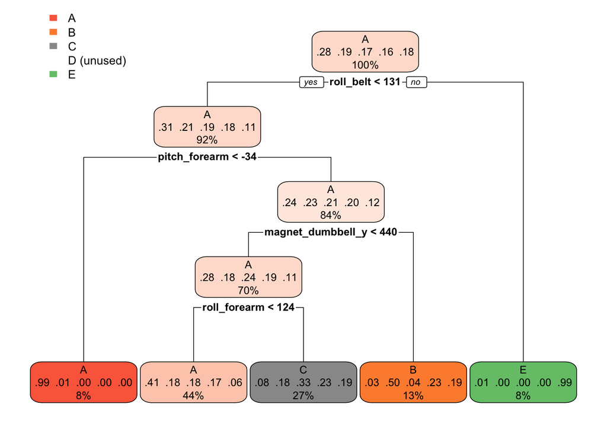

```r
decisionTreeMod <- train(classe ~., method='rpart', data=training_training_data)
rpart.plot(decisionTreeMod$finalModel)
```

```r
#decisionTreePrediction <- predict(decisionTreeMod, training_crossval_data)
#confusionMatrix(training_crossval_data$classe, decisionTreePrediction)
```

## Machine learning with Random Forest

Next we apply the Random Forest algorithm on the training data set and select the best model.

```r
RFcontrol <- trainControl(method="cv", number=3, verboseIter=FALSE)
RFfitMod  <- train(classe ~ ., data=training_training_data, method="rf",
                          trControl=RFcontrol)
RFfitMod$finalModel
```

```
##
## Call:
##  randomForest(x = x, y = y, mtry = param$mtry)
##                Type of random forest: classification
##                      Number of trees: 500
## No. of variables tried at each split: 27
##
##         OOB estimate of  error rate: 0.62%
## Confusion matrix:
##      A    B    C    D    E  class.error
## A 4181    3    0    0    1 0.0009557945
## B   23 2820    5    0    0 0.0098314607
## C    0   10 2550    7    0 0.0066225166
## D    0    2   28 2380    2 0.0132669983
## E    0    1    4    5 2696 0.0036954915
```

```r
RFpredict <- predict(RFfitMod, newdata=training_crossval_data)
```

## Prediction on test data set

```r
predict(RFfitMod, clean_testing_data)
```

```
##  [1] B A B A A E D B A A B C B A E E A B B B
## Levels: A B C D E
```